# T cell analysis

Priyanka Rajan

2/4/2025

## Introduction

The effect of p38 blockade by p38i/p38KO on T cells was analyzed through differential gene expression analysis and pathway analysis. Further, the T cell subtypes present in the dataset is determined using ProjecTILs package(Andreatta, M., et al, 2021)[https://github.com/carmonalab/ProjecTILs]

```r
#Loading libraries
knitr::opts_chunk$set(echo = TRUE)
library(SummarizedExperiment)
library(SingleCellExperiment)
library(fgsea)
library(msigdbr)
library(ggplot2)
library(reshape2)
library(dplyr)
library(Seurat)
library(tidyr)
library(ggsignif)
library(scCustomize)
library(ComplexHeatmap)
library(circlize)
library(ProjecTILs)
library(UCell)
library(scGate)
library(gridExtra)
library(remotes)
library(scCustomize)
library(Matrix)
library(knitr)
setwd("/projects/rpci/avbakin/prajan3")

#Reading the sce object
sce <- readRDS("20220310_subsetted.rds")

#Subsetting to have only T cells
sce.t <- sce[ ,sce$immgenlabel=="T cells"]

#Converting sce to seurat object
sce.seurat <- as.Seurat(sce.t, counts = "counts", data = "logcounts")
Idents(sce.seurat) <- "samplename"

#png function
pngfunc <- function(filename = "mypng.png", width=7, height = 7, units = "in",
                    res = 300, ...){
  png(filename = filename, width = width, height = height, units = units,
            res = res, ...)
}

#function to calculate score
myzeroone <- function(x, low=0){
  x <- (x-min(x[x>low], na.rm=TRUE))/diff(range(x[x>low], na.rm=TRUE))
  x[x<0] <- 0
  x
}
```

## T cell subtype determination using ProjecTILs

To further determine the CD4+ and CD8+ T cell subtypes present, I use [ProjecTILs] (https://github.com/carmonalab/ProjecTILs) package. ProjeTILs is a method to project query scRNA-seq data into reference single-cell atlases, enabling their direct comparison and characterization of cell types. Here I use the mouse TIL atlas consisting of 16,803 single-cell transcriptomes from 25 samples (B16 melanoma and MC38 colon adenocarcinoma tumors) from six different studies. Since projecTILs stores single cell data in a Seurat object, I use Seurat for further downstream analysis.

```r
#load ref
ref <- load.reference.map()
```

```
## [1] "Loading Default Reference Atlas..."
## [1] "/projects/rpci/avbakin/prajan3/ref_TILAtlas_mouse_v1.rds"
## [1] "Loaded Reference map ref_TILAtlas_mouse_v1"
```

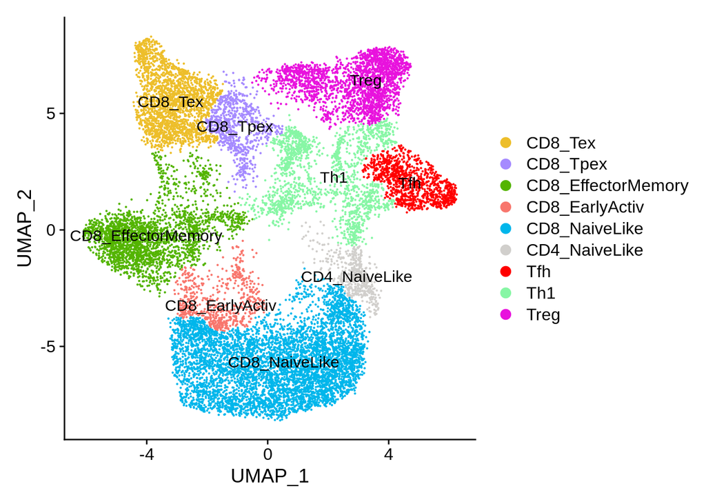

```r
#Check if ref was loaded correctly
refCols <- c("#edbe2a", "#A58AFF", "#53B400", "#F8766D", "#00B6EB", "#d1cfcc", "#FF0000", "#87f6a5", "#e812dd")
DimPlot(ref,label = T, cols = refCols)
```

```r
#split object
data.split <- SplitObject(sce.seurat, split.by = "samplename")

#Make projection
query.projected <- make.projection(data.split, ref, filter.cells = F)
```

```
##
## [1] "Aligning 4T1-Tu to reference map for batch-correction..."
##
## Projecting corrected query onto Reference PCA space
##
## Projecting corrected query onto Reference UMAP space
##
## [1] "Aligning 4T1-Tu-plus-p38i to reference map for batch-correction..."
##
## Projecting corrected query onto Reference PCA space
##
## Projecting corrected query onto Reference UMAP space
##
## [1] "Aligning p38a-ko-H9 to reference map for batch-correction..."
##
## Projecting corrected query onto Reference PCA space
##
## Projecting corrected query onto Reference UMAP space
##
```

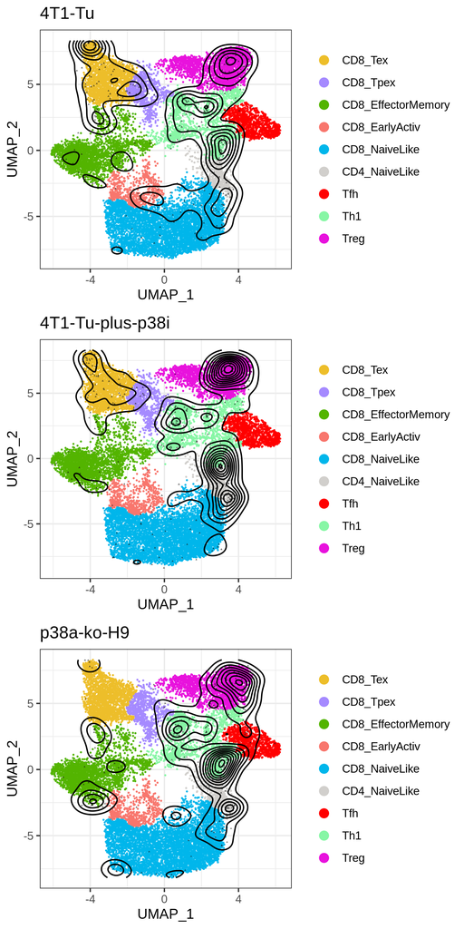

```r
#The function make.projection() doesn't assign the cell states yet. The cellstate.predict function in the #plot section below assigns the cell states.

#Plot
p <- list()
for(i in seq_along(query.projected)){
  s <- names(query.projected)[i]
  query.projected[[s]] <- cellstate.predict(ref = ref, query = query.projected[[s]])
  p[[i]] <- plot.projection(ref, query = query.projected[[i]], linesize = 0.5, pointsize = 0.2) + ggtitle(s) +
    theme(aspect.ratio = 0.8) + theme_bw()
  write.table(table(query.projected[[s]]$functional.cluster), paste0("T cell analysis/reports/",s,"_TILs_v3.tsv"), sep = "\t")
}

pngfunc("Plots/QC2/T/projectils_tsne.png", height = 10, width = 5)

do.call("grid.arrange", c(p, nrow=3))

invisible(dev.off())
include_graphics("Plots/QC2/T/projectils_tsne.png", dpi = 300)
```

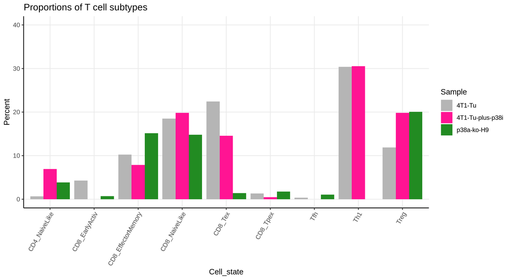

```r
#Frequency of T cell subtypes present in each sample
mylist <- vector("list", length(names(query.projected)))
names(mylist) <- names(query.projected)

for (i in names(query.projected)){
  df <- table(query.projected[[i]]$functional.cluster)
  df <- as.data.frame(df)
  df$Percent <- df$Freq/sum(df$Freq) * 100
  df$Sample <- rep(i, nrow(df))
  names(df)[1] <- "Cell_state"
  mylist[[i]] <- df
}

#Combine 3 lists onto one data frame
DF <- Reduce(function(...) merge(..., all=TRUE), mylist)

#p38i doesnt have any CD8earlyactiv or Tfh. We need to introduce those labels with 0 as frequency or else the plot looks incorrect
toadd <- data.frame(c("CD8_EarlyActiv", "Tfh"),
                    c(0,0),
                    c(0.00,0.00),
                    c("4T1-Tu-plus-p38i","4T1-Tu-plus-p38i"))
names(toadd) <- c("Cell_state", "Freq", "Percent", "Sample")

#use rbind
DF1 <- rbind(DF, toadd)

#Barplot of cell state percentages
pngfunc("Plots/QC2/T/Cell_states.png", width = 10, height  = 5.5)

ggplot(DF1, aes(fill=Sample, x=Cell_state, y=Percent)) +
  geom_bar(position="dodge", stat="identity")+
  ggtitle("Proportions of T cell subtypes") +
  theme_bw() +
  theme(axis.text.x = element_text(size = 9), axis.text.y = element_text(size = 9)) +
  scale_fill_manual(values = c("gray71", "deeppink", "forestgreen")) +
  scale_y_continuous(limits=c(0,40)) +
  theme(axis.text.x = element_text(angle = 60, vjust = 1, hjust=1)) +
 theme(axis.line = element_line(color='black'),
    plot.background = element_blank(),
    panel.grid.minor = element_blank(),
    panel.border = element_blank())

invisible(dev.off())
include_graphics("Plots/QC2/T/Cell_states.png", dpi = 300)
```

## Differentially expressed genes between treatment groups

ProjecTILs generates seurat object for each sample and combines the samples into a list. I used the Merge_Seurat_List() from scCustomize package to remove the objects from the list and merge them into a single seurat object. Then, I used the [FindMarkers()] (https://satijalab.org/seurat/articles/de_vignette) function from Seurat to determine genes differentially expressed in T cells in p38i/p38KO tumors compared to vehicle control. This is done by setting ident.1 as p38i or p38KO and ident.2 as vehicle, the function calculates genes that are differentially expressed in p38i or p38KO samples compared to vehicle control. Seurat offers a variety of DE tests to opt from. I used MAST, a commonly used test for scRNAseq data that treates cellular detection rate as a covariate (Finak et al, Genome Biology, 2015). Min.pct() only tests DE in genes that are expressed in atleast min.pct of cells in each samples. Here I set the minimum percent as 5. Heatmaps were created using [ComplexHeatmap package] (https://jokergoo.github.io/ComplexHeatmap-reference/book/a-single-heatmap.html).

```r
#Create one seurat object with all 3 samples
seurat.tils <- Merge_Seurat_List(query.projected, add.cell.ids = NULL, merge.data = TRUE)
Idents(seurat.tils) <- "samplename"

#Perform DGE analysis using findmarkers function from seurat
#Setting ident.1 as p38i or p38KO and ident.2 as vehicle control

diff1 <- FindMarkers(seurat.tils, ident.1 = "4T1-Tu-plus-p38i", ident.2 = "4T1-Tu", assay = "integrated", slot = "data", test.use = "MAST", min.pct = 0.05, logfc.threshold = 0)
dge1 <- diff1[diff1$p_val<0.05, ]

diff2 <- FindMarkers(seurat.tils, ident.1 = "p38a-ko-H9", ident.2 = "4T1-Tu", assay = "integrated", slot = "data", test.use = "MAST", min.pct = 0.05, logfc.threshold = 0)
dge2 <- diff2[diff2$p_val<0.05, ]

#Heatmap to plots average expression of cells in a group
#Creating a list of genes defining T cell activation, differentiation, effector and exhaustion
genes <- c("Slamf6", "Xcr1", "Bcl2a1b", "Icos", "Cd40lg", "Tnfrsf4", "Tnfsf8", "Ifngr2", "Il2", "Cxcr5", "Cxcr3", "Cxcr4", "Ccr7", "Ccr5", "Ccr2", "Ccr4", "Ccr6", "Itgae", "Itgb7", "Gzmk", "Prf1", "Gzmc", "Nkg7", "Klrd1", "Fasl", "Pdcd1lg2", "Lag3", "Ctla4", "Pdcd1", "Lgals3", "Havcr2")

#extracting average counts for the genes from the seurat object
mean_mat <- AverageExpression(seurat.tils, group.by = "samplename", assay = "integrated",
                              layer = "data", features = genes)
mat <- mean_mat[[1]]

#scaling matrix
mat <- t(scale(t(mat)))

#defining row and column names
rownames(mat) <- genes
colnames(mat) <- c("Veh", "p38i", "p38ko")

cluster_anno <- unique(seurat.tils$samplename)

#defining 10th and 95th percentiles
quantile(mat, c(0.1, 0.95))
```

```
##       10%       95%
## -1.042391  1.142329
```

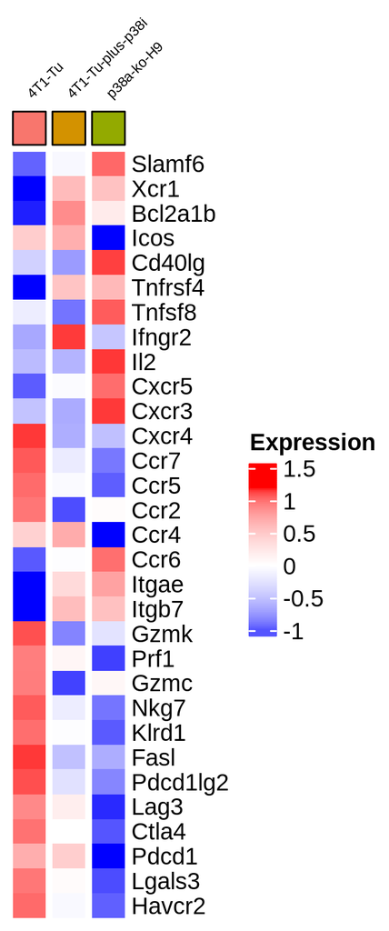

```r
#setting the limits for color ramp using 10th and 95th percentiles
f1 = colorRamp2(c(-1.1,0,1.2), c("blue","white","red"), space = "RGB")

#heatmap
pngfunc("Plots/QC2/T/Heatmap_Tcells.png", width = 2.3, height  = 5.5)
Heatmap(mat,
        name="Expression",
        cluster_rows = FALSE,
        col = f1,
        column_split = cluster_anno,
        cluster_columns = FALSE,
        show_column_dend = FALSE,
        cluster_column_slices = TRUE,
        column_title_gp = gpar(fontsize=6),
        row_names_gp = gpar(fontsize=10),
        column_title_rot = 45,
        top_annotation = HeatmapAnnotation(foo=anno_block(gp=gpar(fill=scales::hue_pal()(9)))),
        show_column_names = FALSE,
        use_raster = TRUE,
        raster_quality = 4
)
invisible(dev.off())
include_graphics("Plots/QC2/T/Heatmap_Tcells.png", dpi = 300)
```

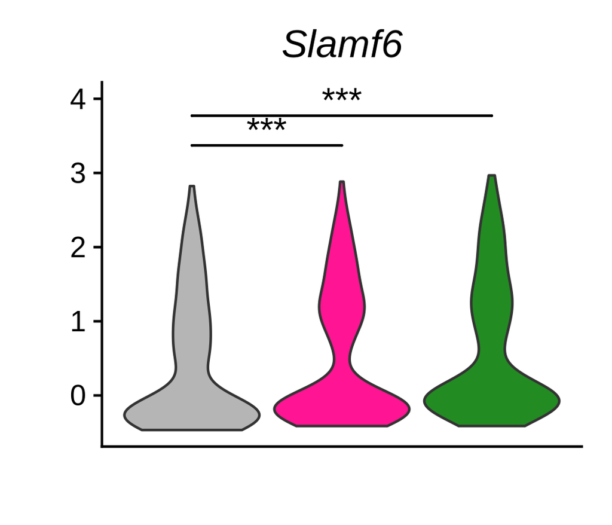

```r
#violin plot showing distribution of read counts for a gene
#Here I am showing the distribution for Slamf6, a transcription factor regulating T cell differentiation to T-helper subsets

pngfunc("Plots/QC2/T/Slamf6.png", width = 3.5, height = 3)

VlnPlot(seurat.tils, features = "Slamf6", pt.size = 0, group.by = "samplename", assay = "integrated", layer = "data") + labs(title = "Slamf6", x = "", y = "") + theme(axis.text.x = element_blank(), axis.ticks.x = element_blank(), legend.position = "none", plot.title = element_text(face = "italic", hjust = 0.5)) +
geom_signif(comparisons = list(c("4T1-Tu-plus-p38i", "4T1-Tu"), c("p38a-ko-H9", "4T1-Tu")), test = "wilcox.test" , test.args = list(alternative = "two.sided", var.equal = FALSE, paired = FALSE),
map_signif_level = TRUE, textsize = 5, y_position = c(3.2, 3.6), tip_length = 0) + ylim(NA, 4) +
  scale_fill_manual(values = c("gray71", "deeppink", "forestgreen"))

invisible(dev.off())
include_graphics("Plots/QC2/T/Slamf6.png", dpi = 300)
```

## Gene set enrichment analysis (GSEA)

The [msigdbr] (https://cran.r-project.org/web/packages/msigdbr/vignettes/msigdbr-intro.html) R package provides gene sets from Molecular Signatures Database (MSigDB) typically used with the Gene Set Enrichment Analysis (GSEA) software. I used the biological processes dataset from the mouse gene ontology database. To perform the analysis, I used the fast GSEA [fGSEA] (https://bioconductor.org/packages/release/bioc/vignettes/fgsea/inst/doc/fgsea-tutorial.html).

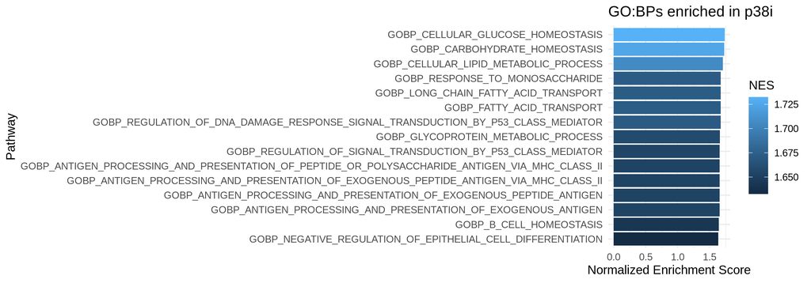

```r
#Gene set enrichment analysis
#Loading Mouse Gene Ontology database: Biological processes dataset from MSIGDB-Broad Institute
m_gene_sets <-msigdbr(species = "mouse", category = "C5", subcategory = "GO:BP")
msigdb_list_go_bp <- split(x=m_gene_sets$gene_symbol, f=m_gene_sets$gs_name)

#Creating a numeric vector of log2FC values from the DGE analysis of p38i vs veh
ranks <- dge1[,2]
names(ranks) <- rownames(dge1)

#Ranking - arranging in decreasing order of logFC values
ranks <- sort(ranks, decreasing = TRUE)

#Running GSEA using fGSEA
fgseares1 <- fgsea(msigdb_list_go_bp, stats=ranks)

fgseares1 <- fgseares1 %>% as_tibble() %>% arrange(desc(NES)) %>% filter(pval<0.05)

df_res1 = data.frame(lapply(fgseares1, as.character), stringsAsFactors=FALSE)

#Barplot
pngfunc("Plots/QC2/T/i_vs_v_GO.png", width = 10, height = 3.5)
ggplot(fgseares1  %>% head(n=15),
       aes(reorder(pathway,NES), NES)) +
        geom_col(aes(fill=NES)) +
        coord_flip()+ labs(x="Pathway", y="Normalized Enrichment Score",
                           title="GO:BPs enriched in p38i") +
        theme_minimal()
invisible(dev.off())
include_graphics("Plots/QC2/T/i_vs_v_GO.png", dpi = 300)
```

## CD4+ and CD8+ T cell analysis

The DGE analysis of T cells shows decrease in T cell exhaustion molecules upon p38 blockade but it is unclear if these changes are specific to CD8+ T cells. To investigate these changes, I further subsetted T cells into CD4+ and CD8+ populations using a function to score cells based on the expression level of CD4 and CD8.

```r
#Generating list of CD4+ and CD8+ T cell markers
genesets <- list(
  "CD4+ T cell" = c("Cd4"),
  "CD8+ T cell" = c("Cd8a"))

#Calculating each cell's expression level of those markers and generate a score from 0 to 1
scores <- sapply(genesets, function(x){
  y <- cpm(sce.t[x])
  myzeroone(rowSums(apply(y, 1, myzeroone)))
})

scores <- t(apply(scores + 1e-5, 1, function(x) x/sum(x)))

#Determining the subtype
sce.t$subtype <- colnames(scores)[apply(scores, 1, which.max)]

#Creating sce objects for each subtype
sce.tc.cd4 <- sce.t[ ,sce.t$subtype == "CD4+ T cell"]
sce.tc.cd8 <- sce.t[ ,sce.t$subtype == "CD8+ T cell"]

#Converting sce to seurat object
sce.cd4.seurat <- as.Seurat(sce.tc.cd4, counts = "counts", data = "logcounts")
Idents(sce.cd4.seurat) <- "samplename"

sce.cd8.seurat <- as.Seurat(sce.tc.cd8, counts = "counts", data = "logcounts")
Idents(sce.cd8.seurat) <- "samplename"

#Assessing the expression of T cell exhaustion molecules among the CD8+ T cells
genes <- c("Pdcd1lg2", "Lag3", "Ctla4", "Pdcd1", "Lgals3", "Havcr2", "Foxp3")

#creating heatmap
mean_mat <- AverageExpression(sce.cd8.seurat, group.by = "samplename", assay = "originalexp", layer = "data", features = genes)

mat <- mean_mat[[1]]

mat <- t(scale(t(mat)))
rownames(mat) <- genes
colnames(mat) <- c("Veh", "p38i", "p38ko")

cluster_anno <- unique(sce.cd4.seurat$samplename)

quantile(mat, c(0.1, 0.95))
```

```
##        10%        95%
## -0.9041875  1.1497150
```

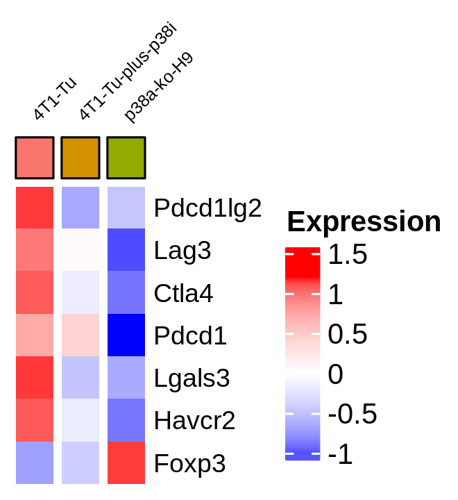

```r
f1 = colorRamp2(c(-1.1,0,1.2), c("blue","white","red"), space = "RGB")
pngfunc("Plots/QC2/T/Heatmap_CD8Tcells.png", width = 2.2, height  = 2.4)
Heatmap(mat,
        name="Expression",
        cluster_rows = FALSE,
        col = f1,
        column_split = cluster_anno,
        cluster_columns = FALSE,
        show_column_dend = FALSE,
        cluster_column_slices = TRUE,
        column_title_gp = gpar(fontsize=6),
        row_names_gp = gpar(fontsize=9),
        column_title_rot = 45,
        top_annotation = HeatmapAnnotation(foo=anno_block(gp=gpar(fill=scales::hue_pal()(9)))),
        show_column_names = FALSE,
        use_raster = TRUE,
        raster_quality = 4
)
invisible(dev.off())
include_graphics("Plots/QC2/T/Heatmap_CD8Tcells.png", dpi = 300)
```

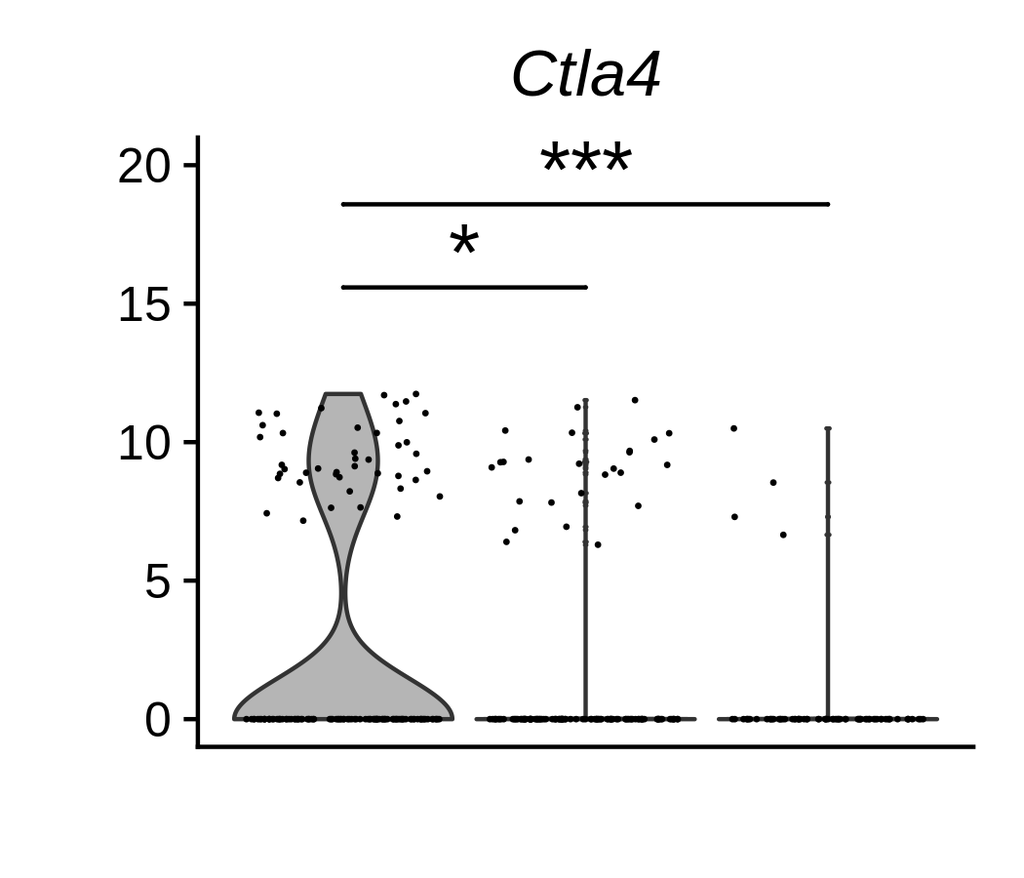

```r
#Violin plot for Ctla4
pngfunc("Plots/QC2/T/Ctla4.png", width = 3.5, height = 3)

VlnPlot(sce.cd8.seurat, features = "Ctla4", pt.size = 0.1, group.by = "samplename", assay = "originalexp", layer = "data") + labs(title = "Ctla4", x = "", y = "") + theme(axis.text.x = element_blank(), axis.ticks.x = element_blank(), legend.position = "none", plot.title = element_text(face = "italic", hjust = 0.5)) +
geom_signif(comparisons = list(c("4T1-Tu-plus-p38i", "4T1-Tu"), c("p38a-ko-H9", "4T1-Tu")), test = "t.test" , test.args = list(alternative = "two.sided", var.equal = FALSE, paired = FALSE),
map_signif_level = TRUE, textsize = 7, y_position = c(15, 18), tip_length = 0) + ylim(NA, 20) +
  scale_fill_manual(values = c("gray71", "deeppink", "forestgreen"))

invisible(dev.off())
include_graphics("Plots/QC2/T/Ctla4.png", dpi = 300)
```